# Path2D

# Path2D and PathFollow2D constrain the movement of child nodes

`Path2D` lets you design a smooth curve with [Bezier interpolation](https://en.wikipedia.org/wiki/B%C3%A9zier_curve), as seen in vector drawing programs like Affinity Designer or Inkscape. The `PathFollow2D` node moves along a parent `Path2D` and makes its children follow the path.

You can either draw the path in the viewport or generate curves at runtime. In turn, the two nodes are great for path-following mechanics.

For example, using `Path2D` and `PathFollow2D`, you could use the `AStar` pathfinding algorithm to construct paths for units to follow at runtime in a top-down grid-based game.

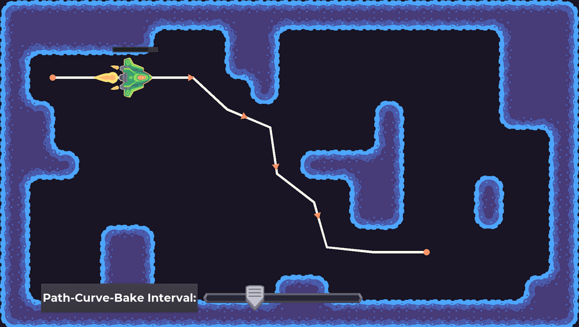

`Path2D` node can work on its own without the `PathFollow2D` child. We’ll cover this when generating a laser beam that shoots from off-screen onto a target.

On the other hand, `PathFollow2D` only works as a child of `Path2D`, where it gets constrained on the parent’s curve.

In this guide, you’ll learn to:

- Set up the `Path2D` and `PathFollow2D` combo for making nodes follow a designated path.
- Make a player unit move along a path generated using an `AStar` algorithm in real-time. We’ll also see how to deal with hitpoints that follow the unit without rotating along the path.
- Generate a random path for a card game for an effective animation.
- Move a platform on a predefined path in a side-scroll demo.
- Create a sweeping laser animation with off-screen origin.
- Use the `Path2D` and `PathFollow2D` in a non-standard way to create a directed force field that influences `RigidBody2D` nodes.

Contents:

- Setting up a Path2D and PathFollow2D to move along the path
- Path2D’s key features
  - The Curve2D resource
- PathFollow2D’s key features
  - Offset-based position and rotation
  - Smooth paths with cubic interpolation
  - Optional rotation along the curve
  - Horizontal and vertical offsets
  - Looping and cyclic curves
- How to use Path2D and PathFollow2D in practice
  - Real-time paths for the AStar algorithm
  - Player-following health bar
  - Random paths for card games
  - Side-scroller platforms following a complex path
  - Paths as force fields
  - Laser swiping effect
  - Your questions
  - How do we create regular geometric paths (ellipses, rectangles, etc.)?

## Setting up a Path2D and PathFollow2D to move along the path

To follow a `Path2D` node’s curve, you must add a `PathFollow2D` node as a child of it, like so:

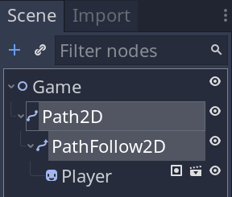

To draw a path, you need to add a new `Curve2D` to the `Path2D`’s *Curve* property.

You can then draw the path in the 2D viewport using the toolbar that appears at the top:

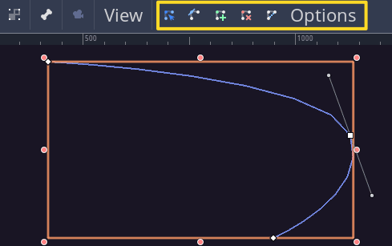

Then you can manipulate the location of `PathFollow2D` along the curve using either its *Offset* or *Unit Offset* in the *Inspector*:

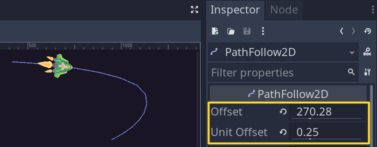

Updating either property automatically updates the other.

## Path2D’s key features

The purpose of the `Path2D` node is to hold the `Curve2D` resource. This is its key property.

### The Curve2D resource

You can either draw the curve in the 2D viewport in the editor or manipulate it in code. Both ways are helpful depending on the case.

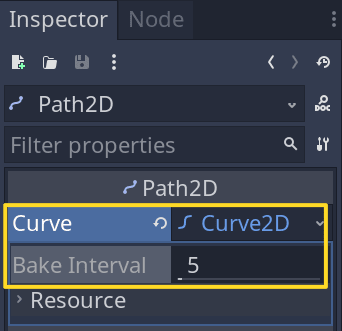

To save on performance, the node precalculates points along the curve using the *Bake Interval* property. This value represents the distance in pixels between two of those points.

By default, the `Curve2D` resource uses a *Bake Interval* of `5` pixels, meaning it’ll precalculate one point every `5` pixels.

As we’ll see, this property, combined with `PathFollow2D`’s *Cubic Interp* property, can generate smooth paths, even if we have a `Curve2D` with sharp corners.

Here’s a preview with *Bake Interval* set to `250` and *Cubic Interp* both on and off:

[figure not shown]

[figure not shown]

**Note:** If the *Bake Interval* is too large, the arcs followed by `PathFollow2D` can end up very different from the smooth curve you drew. For performance reasons, the engine calculates a limited number of vertices when drawing the curve based on the Bake Interval property.

## PathFollow2D’s key features

`PathFollow2D` only works as a child of a `Path2D` node. Its key features are that it moves and rotates along its parent path.

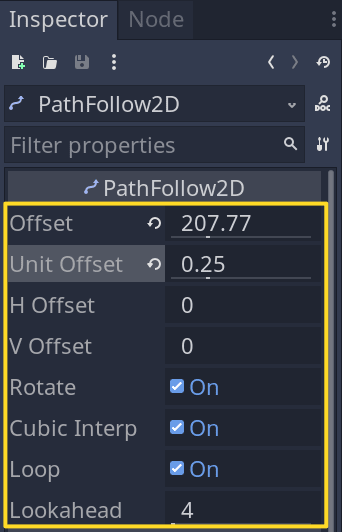

### Offset-based position and rotation

You control the node’s position along the parent path using either the *Offset* or the *Unit Offset* property.

Changing either property causes the other to update as well. The main difference is that the *Offset* is in pixels while the *Unit Offset* is in the `[0, 1]` range.

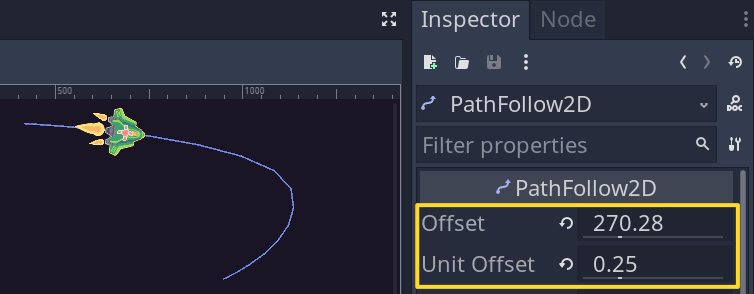

### Smooth paths with cubic interpolation

As we saw, the actual path taken by `PathFollow2D` is influenced by `Curve2D`’s *Bake Interval* property.

Especially when *Cubic Interp* is on, this smooths the interpolation between the cached curve points, even if the curve is created with sharp corners.

[figure not shown]

### Optional rotation along the curve

The other notable feature of `PathFollow2D` is the *Rotate* property. If it’s on, the node will also align its rotation to match the curve direction.

The *Lookahead* property also influences the rotation. Smaller values lead to faster rotations.

### Horizontal and vertical offsets

As the name implies, *H Offset* and *V Offset* add horizontal and vertical offsets to the position of the `PathFollow2D` node.

For example, by duplicating the `PathFollow2D` twice:

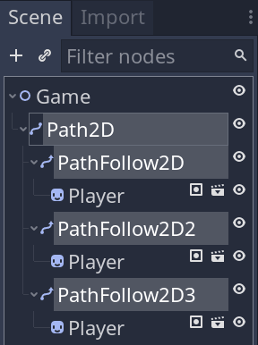

And setting the *H Offset* and *V Offset* to `-150` on one and *H Offset* to `-150` and *V Offset* to `150` on the other, we get a uniform mob movement:

[figure not shown]

Although this setup looks very mechanical, if you add a bit of randomness to the *H Offset* and *V Offset* properties, it can give interesting results.

### Looping and cyclic curves

Finally, when on, the *Loop* property will force any *Offset* value outside the `Curve2D` length to wrap around. This is useful for cyclic paths. We create a cyclic path by having the first and last points coincide.

There’s no need to place the last point of the curve manually. We can generate a final point that coincides perfectly with the first using the *Close Curve* button from the toolbar:

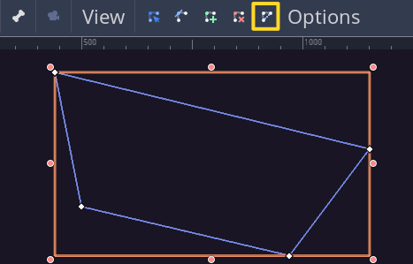

## How to use Path2D and PathFollow2D in practice

In this section, we’ll look at standard examples of using the `Path2D` and `PathFollow2D` combo and some more creative cases.

### Real-time paths for the AStar algorithm

In this example, we have a top-down game that uses a `TileMap` and the `AStar` algorithm to construct a path for the player ship to follow.

We use the `Path2D` and `PathFollow2D` combo to create real-time paths on player mouse click. The path starts at the current ship position and ends at the center of the clicked tile.

We’ll also look at handling an attached UI element that follows the player ship but doesn’t rotate with it.

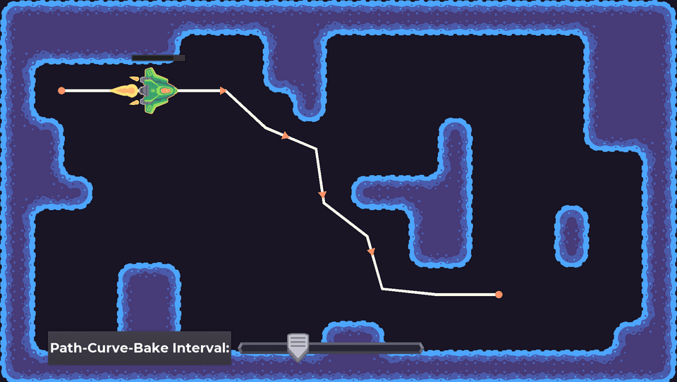

To find and follow paths, we use the following nodes:

- A `TileMap` serves as the game’s grid. We treat occupied cells as obstacles.
- A `Path2D` with a child `PathFollow2D` to respectively generate a curve and follow it.
  - We add a character as a child of the `PathFollow2D`, a `Sprite`, that’ll automatically move along with its parent.

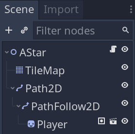

We make sure to turn off the `PathFollow2D`’s *Loop* property. Otherwise, the ship will restart the path movement from the beginning forever.

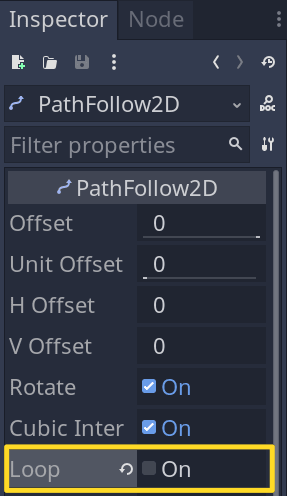

We then reference our necessary nodes from code:

```
# We reference our scene's three key nodes and use them for pathfinding.
onready var _tilemap: TileMap = $TileMap
onready var _path: Path2D = $Path2D
onready var _path_follow: PathFollow2D = $Path2D/PathFollow2D
```

Moving the `PathFollow2D` node along the `Path2D`’s `Curve` is done in `_process()`. By default, we disable `_process()` and only enable it when a new curve is calculated based on the player mouse input.

We need a few variables for calculating the player ship speed:

```
## The ship's maximum speed in pixels per second.
const SPEED_MAX := 550.0

var _acceleration := 1000.0
## The ship's current speed in pixels per second.
var _speed := 0.0
```

And then, in the `_process()` function:

```
# We reference our scene's three key nodes and use them for pathfinding.
onready var _tilemap: TileMap = $TileMap
onready var _path: Path2D = $Path2D
onready var _path_follow: PathFollow2D = $Path2D/PathFollow2D

func _process(delta: float) -> void:
    _speed = min(_speed + _acceleration * delta, SPEED_MAX)
    _path_follow.offset += _speed * delta

    if _path_follow.offset >= _path.curve.get_baked_length():
        _speed = 0.0
        set_process(false)
```

To construct the curve based on the `AStar` algorithm and issue the move command, we:

1. Get the `AStar` path.
2. Clear the current `Path2D` *Curve* and add the points from step one to it.
3. Enable `_process()` to start the ship movement.

To get the ship to move along the path, we call two functions, `find_path_to()` and `move_along()`.

```
func _unhandled_input(event: InputEvent) -> void:
    if event.is_action_pressed("click"):
        move_along(find_path_to(event.position))
```

The `find_path_to()` function asks the `AStar2D` object for a path, an array of grid coordinates to move to the target position.

```
## Gets the `AStar` point-path given by the `PathFollow2D` current position and the
## input `mouse_position`.
func find_path_to(mouse_position: Vector2) -> PoolVector2Array:
    var out: PoolVector2Array = []

    # First get the start and finish `AStar` indices based on `PathFollow2D` and respectively
    # the mouse click locations.
    var start_index := xy_to_index(_tilemap.world_to_map(_path_follow.position))
    var finish_index := xy_to_index(_tilemap.world_to_map(mouse_position))
    if _astar.has_point(start_index) and _astar.has_point(finish_index):
        out = _astar.get_point_path(start_index, finish_index)

    return out
```

We define two utility functions to convert 2D coordinates to unique indices and vice-versa. We need this as the pathfinding algorithm works with indices.

```
# We use the following two functions to convert values between grid coordinates
# and indices.
func xy_to_index(offset: Vector2) -> int:
    return int(offset.x + _tilemap_rect.size.x * offset.y)


func index_to_xy(index: int) -> Vector2:
    return Vector2(index % int(_tilemap_rect.size.x), index / int(_tilemap_rect.size.x))
```

Last is the `move_along()` function which takes the path output by `find_path_to()` and updates the `Path2D` node’s `curve` for the ship to move to the target.

```
## Updates the `Path2D.curve` property based on the input `AStar` point-path and starts the
## player movement.
func move_along(path: Array) -> void:
    if path.empty():
        return

    # Clear the curve points and add the current `PathFollow2D` position as the first point.
    # This way, we can calculate new paths mid-movement.
    _path.curve.clear_points()
    _path.curve.add_point(_path_follow.position)

    # We skip the first points since we already added the `PathFollow2D` position.
    for index in range(1, path.size()):
        # Get point in world coordinates and correct for tile center.
        var point := _tilemap.map_to_world(path[index])
        point += _tilemap.cell_size / 2
        _path.curve.add_point(point)

    # Reset the `PathFollow2D` offset and enable `_process()` to start the movement.
    _path_follow.offset = 0.0
    set_process(true)
```

### Player-following health bar

We often need to make UI widgets follow moving entities, like a life bar that displays right above a ship.

However, if you add the bar as a child of the ship, it will rotate with its parent.

When the entity moves along a path using `PathFollow2D`, there are several ways we can go about moving the UI at an offset:

1. Create an extra `PathFollow2D` specially made for the health bar and turn off *Rotate* in the *Inspector*. In this case, we need to sync its `offset` property with the other `PathFollow2D` node in code.
2. Use a `RemoteTransform2D` node to forward the ship’s position to the life bar with an offset.

We explore the second option here because it doesn’t require any extra code.

We start with the same setup as the previous example: a `TileMap` for the level, a `Path2D`, and a `PathFollow2D`.

As a child of the `PathFollow2D`, we have a `RemoteTransform2D` node to forward the player’s position to the health bar.

We separate the health bar from the `PathFollow2D` to keep it upright. As the `ProgressBar` node we use is a UI node, the `RemoteTransform2D` couldn’t directly control it.

This is why it has a parent `Node2D` named *Health*.

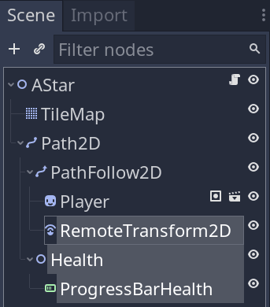

It’s up to you to give the health an appropriate offset relative to the parent `Node2D`:

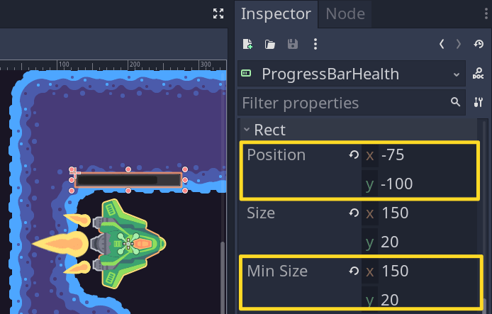

As for the `RemoteTransform2D` node, we assign the `ProgressBar` node’s parent to *Remote Path* and turn off *Rotation*:

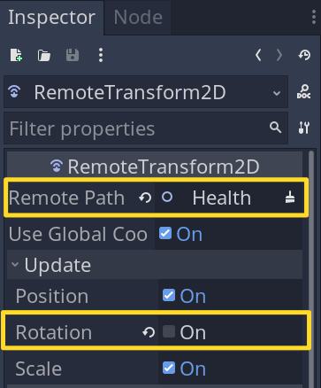

Now, whenever we update the `PathFollow2D`’s *Offset* property, the `RemoteTransform2D` also updates the placement of the health bar without affecting its rotation:

[figure not shown]

You can learn more about using the `RemoteTransform2D` node in the RemoteTransform2D guide.

### Random paths for card games

In this demo, we animate cards moving from the player’s hand to the table slots.

To do so, we generate random motion paths.

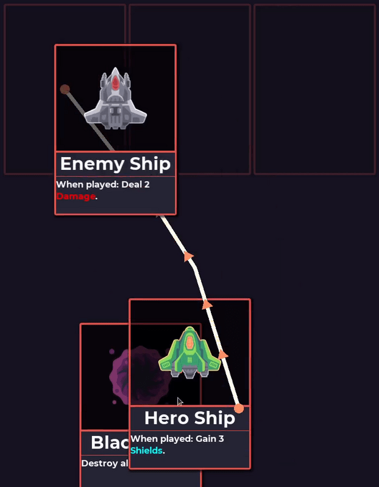

This example uses this scene setup:

- The *Slots* are locations to which the cards can move.
- Each card lives in the *Hand* and is composed of:
  - A `Path2D` with a child `PathFollow2D`.
  - As a child of the `PathFollow2D`, we have the card’s visuals.
  - We use a `Tween` node to animate the `PathFollow2D`’s offset and move the card along the path.

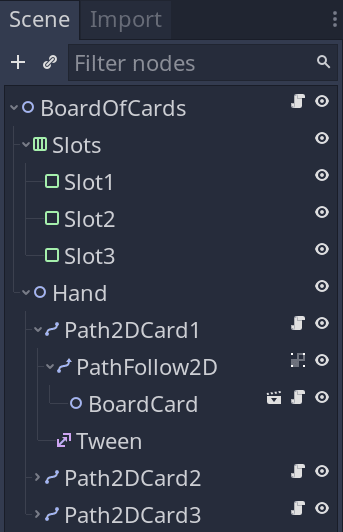

To learn more about designing a card, check out the PanelContainer guide.

To animate the cards, we calculate a path with three points, where the first and last are:

1. The first point is the card’s position.
2. The last point is the position of the first empty slot from the left.

To add variety to the animation, we construct the curve’s middle point by first calculating the average position between the first and last point.

Then we add a random perturbation horizontally.

Given an array of target positions, a `RandomNumberGenerator`, and references to the relevant nodes, we can construct a curve when the player clicks on a card.

We attach the following code to each card.

```
## Stores the position of every slot the card can move to.
## See `setup()` below for its initialization.
var _slot_positions := []
var _rng := RandomNumberGenerator.new()

onready var _path_follow: PathFollow2D = $PathFollow2D
onready var _card: Node2D = $PathFollow2D/BoardCard
# Each card has a visual border we use to detect when the player hovers and
# clicks the card. You can do that with any Control node.
onready var _card_border: PanelContainer = $PathFollow2D/BoardCard/CardBorder
onready var _tween: Tween = $Tween

func setup(slot_positions: Array) -> void:
    _slot_positions = slot_positions
```

We handle this interaction in the `_on_CardBorder_gui_input()` function. We first connect to the UI node’s signals in `_ready()`:

```
func _ready() -> void:
    _card_border.connect("gui_input", self, "_on_CardBorder_gui_input")
    _card_border.connect("mouse_entered", self, "_on_CardBorder_mouse_entered_exited", [true])
    _card_border.connect("mouse_exited", self, "_on_CardBorder_mouse_entered_exited", [false])
    _rng.randomize()
```

And for the actual path construction:

```
# The gui_input signal emits when the player applies input to the node, for
# example, by clicking on it. It won't trigger if the player clicks elsewhere on
# the screen.
func _on_CardBorder_gui_input(event: InputEvent) -> void:
    if event.is_action_pressed("click"):
        # Bring the card on top of the others using the `_slot_positions` size.
        z_index = _slot_positions.size()

        # Get the next slot position, this will also shrink the array.
        var slot_position: Vector2 = _slot_positions.pop_back()

        # Find the mean vertical position between the card and the slot and apply
        # a random horizontal offset for added variation.
        var offset: Vector2 = (_path_follow.position + slot_position) / 2.0
        offset.x += _rng.randf_range(-200, 200)

        # Add the points to the curve: the current card position, the middle offset and
        # the final slot position.
        curve.clear_points()
        curve.add_point(_path_follow.position)
        curve.add_point(offset)
        curve.add_point(slot_position)

        # Here, we animate the card moving along the path.
        _tween.stop_all()
        _tween.interpolate_property(
            _path_follow, "unit_offset", 0, 1, 0.6, Tween.TRANS_QUAD, Tween.EASE_OUT
        )
        # We animate the card going up when hovering it with the mouse. So we
        # need to move it back to its original position quickly to avoid having
        # it offset from the card slot.
        _tween.interpolate_property(
            _card, "position:y", _card.position.y, 0, 0.1, Tween.TRANS_CUBIC, Tween.EASE_IN, 0.7
        )
        _tween.interpolate_callback(self, 0.8, "set_z_index", 0)
        _tween.start()

        # Once the player placed a card, they shouldn't be able to click it
        # anymore. That's why we disconnect from the signals.
        _card_border.disconnect("mouse_entered", self, "_on_CardBorder_mouse_entered_exited")
        _card_border.disconnect("mouse_exited", self, "_on_CardBorder_mouse_entered_exited")
        _card_border.disconnect("gui_input", self, "_on_CardBorder_gui_input")
```

### Side-scroller platforms following a complex path

In this example, we construct a platform following an arbitrary curve instead of the regular horizontal or vertical motions.

[figure not shown]

Interestingly enough, this demo doesn’t need any code other than the code for player movement and perhaps interactables, like the coin.

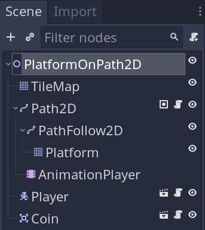

To make the *Platform* do a complete cycle, we animate the `PathFollow2D`’s `unit_offset` property from `0` to `1`:

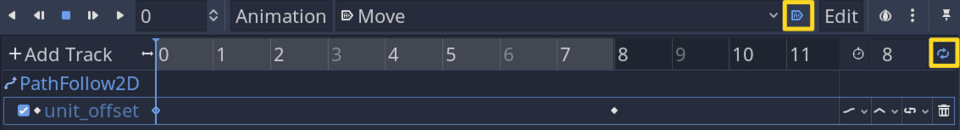

I picked an `8` second long animation for the cycle, made sure to autoplay the *Move* animation, and made it loop.

Because the *Player* is a `KinematicBody2D` node, we need to set the *AnimationPlayer -> Process Mode* to *Physics*. Otherwise, you’ll get jitters and bugs when walking on moving platforms.

This is because we move characters using `_physics_process()` in Godot: we need the animations to synchronize with physics frames for physics interactions to work reliably.

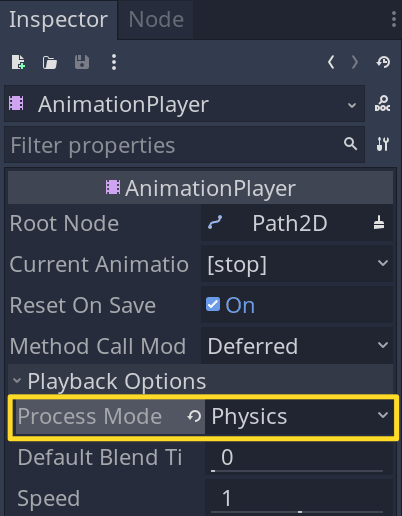

The *Platform* node under `PathFollow2D` is a regular `TileMap` manually constructed around the origin:

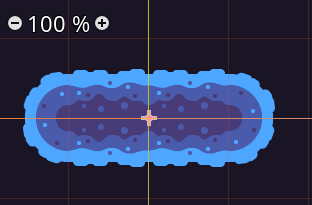

To let the `KinematicBody2D` pass through the *Platform*, we need to turn on *Selected Collision One Way* for all the tiles in the `TileSet` associated with said *Platform*:

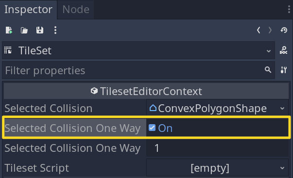

### Paths as force fields

Thinking outside the box, we can use the `Path2D` and `PathFollow2D` combo for other purposes, apart from constraining nodes’ movement on curves.

In this demo, we use paths to construct a force field that directs the movement of `RigidBody2D` nodes:

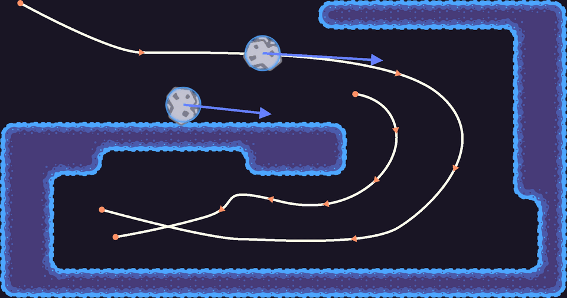

To start us off, we have this scene setup:

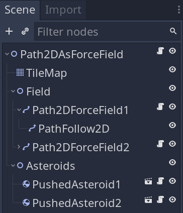

The *Field* contains two paths we use to apply a force to nearby asteroids. The asteroids live under the *Asteroids* node.

On the `Path2D` nodes, we defined a few export variables for easy access in the *Inspector*:

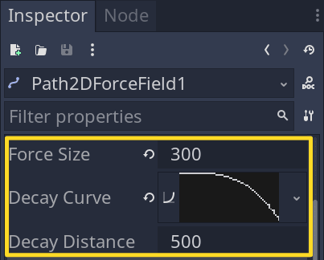

The idea is that the force will be strongest if an asteroid is right on the path, with a value of *Force Size*.

It then decays up to *Decay Distance* following the *Decay Curve* profile.

```
export var force_size := 500.0
export var decay_curve: Curve = Curve.new()
export var decay_distance := 500.0
```

On the root node, we have a script for calculating the force based on the paths and applying it to the `RigidBody2D` nodes under *Asteroids*.

Start by getting references to the appropriate nodes:

```
onready var _field: Node2D = $Field
onready var _asteroids: Node2D = $Asteroids
```

We can calculate the force at a given point any way we want, based on the path. This is how we do it here:

```
## Calculate a force at the given input position, based on the proximity to the
## available paths.
func get_force(input_position: Vector2) -> Vector2:
    var force := Vector2.ZERO

    for path in _field.get_children():
        var path_follow: PathFollow2D = path.get_node("PathFollow2D")

        # Move `PathFollow2D` to the closest point to `input_position`, on the curve.
        path_follow.offset = path.curve.get_closest_offset(input_position)

        # Calculate the force at `distance` given the decay `Curve`.
        var vector_from_input_position := path_follow.position - input_position
        var force_size_at_distance = path.force_size * path.decay_curve.interpolate_baked(
            min(vector_from_input_position.length() / path.decay_distance, 1.0)
        )
        force += force_size_at_distance * path_follow.transform.x

    return force
```

We calculate the total force by adding the contribution to all paths under the *Field* node.

Then for every `RigidBody2D`, in our case called *PushedAsteroid*, we apply the force:

```
func _physics_process(_delta: float) -> void:
    for asteroid in _asteroids.get_children():
        asteroid.applied_force = get_force(asteroid.position)
```